# Some Preperation

First of all, we need to import some function library that we will use in this project,including matplotlib,numpy,cv2 and moviepy.editor

```python
import matplotlib.pyplot as plt
import matplotlib.image as mpimg
import numpy as np
import cv2
import moviepy.editor as mpy
```

# function definition

```python
def region_of_interest(img, vertices):
    """
    Applies an image mask.

    Only keeps the region of the image defined by the polygon
    formed from `vertices`. The rest of the image is set to black.
    """
    # defining a blank mask to start with
    mask = np.zeros_like(img)

    # defining a 3 channel or 1 channel color to fill the mask with depending on the input image
    if len(img.shape) > 2:
        channel_count = img.shape[2]  # i.e. 3 or 4 depending on your image
        ignore_mask_color = (255,) * channel_count
    else:
        ignore_mask_color = 255

    # filling pixels inside the polygon defined by "vertices" with the fill color
    cv2.fillPoly(mask, vertices, ignore_mask_color)

    # returning the image only where mask pixels are nonzero
    masked_image = cv2.bitwise_and(img, mask)
    return masked_image


def hough_lines(img, rho, theta, threshold, min_line_len, max_line_gap):
    """
    `img` should be the output of a Canny transform.

    Returns an image with hough lines drawn.

    """
    height = img.shape[0]
    #width = image.shape[1]
    lines = cv2.HoughLinesP(img, rho, theta, threshold, np.array([]), minLineLength=min_line_len,
                            maxLineGap=max_line_gap)
    line_img = np.zeros([img.shape[0], img.shape[1], 3], dtype=np.uint8)
    if lines != None:
        lines2 = []
        for line in lines:
            for x1, y1, x2, y2 in line:
                k = float(y2 - y1) / (x2 - x1)
                if y1 > y2:
                    x1 = int(x2 + (height - y2) / k)
                    y1 = height
                elif y1 < y2:
                    x2 = int(x1 + (height - y1) / k)
                    y2 = height
                lines2.append([[x1, y1, x2, y2]])
        draw_lines(line_img, lines2, thickness=20)
    return line_img


def draw_lines(img, lines, color=[255, 0, 0], thickness=2):
    """
    Draws `lines` with `color` and `thickness`.

    Lines are drawn on the image inplace (mutates the image).
    """
    for line in lines:
        for x1, y1, x2, y2 in line:
            cv2.line(img, (x1, y1), (x2, y2), color, thickness)


def weighted_img(img, initial_img, a=0.8, b=1., c=0.):
    """
    `img` is the output of the hough_lines(), An image with lines drawn on it.
    Should be a blank image (all black) with lines drawn on it.

    `initial_img` should be the image before any processing.

    The result image is computed as follows:

    initial_img * α + img * β + λ
    NOTE: initial_img and img must be the same shape!
    """
    return cv2.addWeighted(initial_img, a, img, b, c)
```

# key function

Then here is the point.We define a process_image. We use the above mentioned function and defined many key parameters such like gaussianblur and hough line

```python
def process_image(image):
    # TODO: put your pipeline here,
    # you should return the final output (image with lines are drawn on lanes)
    height = image.shape[0]
    width = image.shape[1]
    interest = np.array([[(100,height),(460, 320), (540, 325), (width,height)]], dtype=np.int32)# in normal condition we use these interest region
    #interest = np.array([[(width/4, height*0.9), (width/2, height*0.6), (width*0.55, height*0.6), (width*0.9, height*0.9)]], dtype=np.int32)   #in chanllenge co
  #conditon we use these interest region

    kernel_size = 9
    blur = cv2.GaussianBlur(image, (kernel_size, kernel_size), 0)

    hsv = cv2.cvtColor(blur, cv2.COLOR_RGB2HSV)
    yellow = cv2.inRange(hsv, (20, 50, 50), (50, 255, 255))
    white = cv2.inRange(hsv, (0, 0, 180), (255, 25, 255))
    gray = cv2.bitwise_or(yellow, white)

    low_threshold = 90
    high_threshold = 180
    edges = cv2.Canny(blur, low_threshold, high_threshold)

    roi = region_of_interest(edges, [interest])
   # out = hough_lines(roi, 1, np.pi/180, 10, 50, 25) # in extra condition, we use these parameterjupyter notebook
    out = hough_lines(roi, 1, np.pi / 180, 32, 5, 200) #in normal conditon we use these parameter
    result = weighted_img(image, out, 0.9, 0.9)
    return result
```

# image test

Then we test whether process_image function well using the example picture.

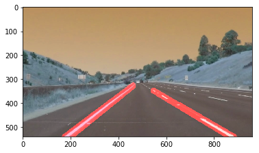

```python
image = cv2.imread('test_images/whiteCarLaneSwitch.jpg')
plt.imshow(process_image(image))
plt.show()
```

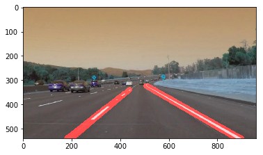

```python
image = cv2.imread('test_images/solidWhiteCurve.jpg')
plt.imshow(process_image(image))
plt.show()
```

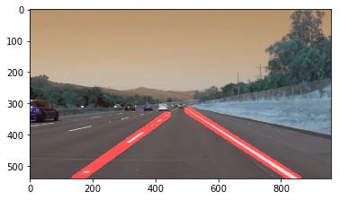

```python
image = cv2.imread('test_images/solidWhiteRight.jpg')
plt.imshow(process_image(image))
plt.show()
```

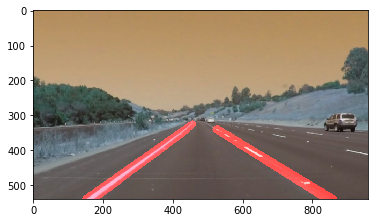

```python
image = cv2.imread('test_images/solidYellowCurve.jpg')
plt.imshow(process_image(image))
plt.show()
```

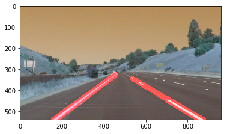

```python
image = cv2.imread('test_images/solidYellowCurve2.jpg')
plt.imshow(process_image(image))
plt.show()
```

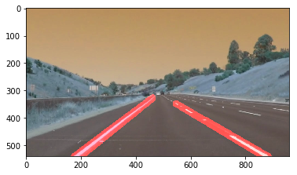

```python
image = cv2.imread('test_images/whiteCarLaneSwitch.jpg')
plt.imshow(process_image(image))
plt.show()
```

# video test

Then we test the video.

```python
white_output = 'test_solidWhiteRight.mp4'
clip1 = mpy.VideoFileClip("test_videos/solidWhiteRight.mp4")
white_clip = clip1.fl_image(process_image)
video = mpy.CompositeVideoClip([white_clip,])
video.write_videofile(white_output, audio=False)
```

```
[MoviePy] >>>> Building video test_solidWhiteRight.mp4
[MoviePy] Writing video test_solidWhiteRight.mp4
```

```
100%|█████████████████████████████████████████████████████████████████████████████████████████████████████████████████████████████████████████████████████████████▎| 221/222 [00:10<00:00, 21.22it/s]
```

```
[MoviePy] Done.
[MoviePy] >>>> Video ready: test_solidWhiteRight.mp4
```

```python
white_output = 'test_solidYellowLeft.mp4'
clip1 = mpy.VideoFileClip("test_videos/solidYellowLeft.mp4")
white_clip = clip1.fl_image(process_image)
video = mpy.CompositeVideoClip([white_clip,])
video.write_videofile(white_output, audio=False)
```

```
[MoviePy] >>>> Building video test_solidYellowLeft.mp4
[MoviePy] Writing video test_solidYellowLeft.mp4
```

```
100%|█████████████████████████████████████████████████████████████████████████████████████████████████████████████████████████████████████████████████████████████▊| 681/682 [00:31<00:00, 21.69it/s]
```

```
[MoviePy] Done.
[MoviePy] >>>> Video ready: test_solidYellowLeft.mp4
```

# chanllenge video

When we test the challenge video,find it functions very badly. So I adjust some parameter for challenge video specially, and name it process_image2. Also,it doesn't fit for normal video. The change focus on the interest region and hough line parameter.

```python
def process_image2(image):
    # TODO: put your pipeline here,
    # you should return the final output (image with lines are drawn on lanes)
    height = image.shape[0]
    width = image.shape[1]
    #interest = np.array([[(100,height),(460, 320), (540, 325), (width,height)]], dtype=np.int32)# in normal condition we use these interest region
    interest = np.array([[(width/4, height*0.9), (width/2, height*0.6), (width*0.55, height*0.6), (width*0.9, height*0.9)]], dtype=np.int32)   #in chanllenge co
  #conditon we use these interest region

    kernel_size = 9
    blur = cv2.GaussianBlur(image, (kernel_size, kernel_size), 0)

    hsv = cv2.cvtColor(blur, cv2.COLOR_RGB2HSV)
    yellow = cv2.inRange(hsv, (20, 50, 50), (50, 255, 255))
    white = cv2.inRange(hsv, (0, 0, 180), (255, 25, 255))
    gray = cv2.bitwise_or(yellow, white)

    low_threshold = 90
    high_threshold = 180
    edges = cv2.Canny(blur, low_threshold, high_threshold)

    roi = region_of_interest(edges, [interest])
    out = hough_lines(roi, 1, np.pi/180, 10, 50, 25) # in extra condition, we use these parameterjupyter notebook
    #out = hough_lines(roi, 1, np.pi / 180, 32, 5, 200) #in normal conditon we use these parameter
    result = weighted_img(image, out, 0.9, 0.9)
    return result
```

so we try again to see if it works well.

```python
white_output = 'test_challenge.mp4'
clip1 = mpy.VideoFileClip("test_videos/challenge.mp4")
white_clip = clip1.fl_image(process_image2)
video = mpy.CompositeVideoClip([white_clip,])
video.write_videofile(white_output, audio=False)
```

```
[MoviePy] >>>> Building video test_challenge.mp4
[MoviePy] Writing video test_challenge.mp4
```

```
100%|██████████████████████████████████████████████████████████████████████████████████████████████████████████████████████████████████████████████████████████████| 251/251 [00:22<00:00, 11.25it/s]
```

```
[MoviePy] Done.
[MoviePy] >>>> Video ready: test_challenge.mp4
```

It comes much better, but still need to improvement.

# Improvement direction

I tried many times to ajust the parameter and it looks that it still can not works perfertly and seems can not works perfectly forever. So the improvement direction is to add some control strategy to tracking this. If some conditon like challenge video happens,firstly we use a different parameter. If stills works bad, then we will need to intervene and lower the dependability of camera and more rely on other sensors like Radars and Lidar temporarily untill the this condtion fade away